# Ejercicio 3: apostadores en casas de apuestas en línea (PCA + clustering)

SESIÓN 18 — APRENDIZAJE NO SUPERVISADO

Autor/a

Jorge Juvenal Campos Ferreira — TC2001B.601

Fecha de publicación

2 de junio de 2026

```r
options(scipen = 999)
```

Contexto del problema:

Una casa de apuestas en línea tiene 700 usuarios descritos por su comportamiento de juego: cuánto depositan, cuánto apuestan, con qué frecuencia y a qué horas juegan, cuánto retiran, cuánto usan bonos, etc. NADIE etiquetó a los usuarios: no sabemos de antemano cuántos “tipos” de jugador hay ni a cuál pertenece cada uno. La pregunta es exploratoria y de negocio (y de juego responsable): **¿existen perfiles de jugador naturales que agrupen a los usuarios?** Segmentarlos permite tratar distinto a un jugador recreativo, a uno de alto valor y a uno con señales de riesgo.

Esto es aprendizaje NO supervisado: no hay variable objetivo (“y”) que predecir, así que NO se parten los datos en entrenamiento/prueba (no hay un acierto que medir). El objetivo es DESCUBRIR e interpretar estructura.

Seguiremos tres pasos, en este orden: 1) PCA: reducir las variables a unos pocos ejes para visualizar y entender qué variables “se mueven juntas”. 2) Clustering k-means, eligiendo el número de grupos con el MÉTODO DEL CODO (y confirmando con la silueta). 3) Graficar los usuarios ya agrupados usando las componentes del paso 1 (PC1 vs PC2), coloreados por cluster. Al final comparamos con clustering jerárquico para dar robustez.

```r
# Librerías ----
library(tidyverse)
library(tidymodels)
library(factoextra)
library(cluster)
```

```r
tidymodels::tidymodels_prefer()
```

## 0. CARGA Y PREPARACIÓN DE LOS DATOS

```r
# Cargamos los 700 usuarios. id_usuario es solo un identificador
# (US00001, US00002, ...): NO es una variable de comportamiento y debe
# removerse antes de cualquier cálculo de distancia (si no, el "id" entraría
# como si fuera un atributo).
apostadores <- read_csv("datos.csv") %>%
  select(-id_usuario)
```

```r
# Inspección rápida: dimensiones, tipos y faltantes.
glimpse(apostadores)
```

```
Rows: 700
Columns: 14
$ edad                        <dbl> 45, 46, 41, 40, 40, 52, 42, 39, 35, 43, 23…
$ antiguedad_dias             <dbl> 498, 1105, 380, 614, 1084, 523, 435, 462, …
$ num_depositos_mes           <dbl> 3, 9, 3, 3, 6, 3, 4, 4, 4, 11, 5, 5, 21, 1…
$ monto_total_depositado_mxn  <dbl> 1344, 22042, 1306, 1438, 23185, 1167, 1015…
$ monto_promedio_apuesta_mxn  <dbl> 79, 940, 71, 63, 689, 47, 34, 45, 52, NA, …
$ num_apuestas_mes            <dbl> 26, 118, 37, 41, 100, 38, 43, 46, 37, 105,…
$ num_sesiones_mes            <dbl> 6, 17, 8, 6, 17, 7, 6, 7, 7, 20, 18, 18, 2…
$ duracion_sesion_min         <dbl> 30, 46, 33, 46, 44, 31, 37, 22, 21, 56, 22…
$ pct_apuestas_nocturnas      <dbl> 17.4, 40.1, 18.8, 37.2, 40.7, 23.1, 35.4, …
$ num_juegos_distintos        <dbl> 9, 6, 5, 4, 5, 3, 5, 7, 4, 5, 12, 13, 4, 2…
$ pct_uso_bonos               <dbl> 14.6, 2.3, 22.3, 23.9, 19.7, 26.9, 16.9, 2…
$ indice_persecucion_perdidas <dbl> 0.233, 0.326, 0.000, 0.042, 0.364, 0.138, …
$ monto_total_retirado_mxn    <dbl> 381, 14788, 726, 736, 9585, 641, 510, 891,…
$ perdida_neta_mxn            <dbl> 963, 7254, 580, 702, 13600, 526, 505, 637,…
```

```r
summary(apostadores)
```

```
      edad      antiguedad_dias  num_depositos_mes monto_total_depositado_mxn
 Min.   :18.0   Min.   :  17.0   Min.   : 1.000    Min.   :  476
 1st Qu.:30.0   1st Qu.: 314.0   1st Qu.: 3.000    1st Qu.: 1152
 Median :38.0   Median : 458.0   Median : 5.000    Median : 3906
 Mean   :37.3   Mean   : 509.6   Mean   : 7.991    Mean   : 9136
 3rd Qu.:44.0   3rd Qu.: 666.2   3rd Qu.: 9.000    3rd Qu.:16346
 Max.   :59.0   Max.   :1445.0   Max.   :38.000    Max.   :43804

 monto_promedio_apuesta_mxn num_apuestas_mes num_sesiones_mes
 Min.   :  24.0             Min.   : 11.0    Min.   : 3.00
 1st Qu.:  54.0             1st Qu.: 37.0    1st Qu.: 7.00
 Median :  74.0             Median : 81.0    Median :12.00
 Mean   : 239.9             Mean   :133.9    Mean   :16.83
 3rd Qu.: 254.0             3rd Qu.:237.2    3rd Qu.:20.00
 Max.   :1415.0             Max.   :482.0    Max.   :61.00
 NA's   :28
 duracion_sesion_min pct_apuestas_nocturnas num_juegos_distintos
 Min.   :  7.0       Min.   : 0.00          Min.   : 1.000
 1st Qu.: 24.0       1st Qu.:19.38          1st Qu.: 4.000
 Median : 34.0       Median :25.90          Median : 5.000
 Mean   : 43.7       Mean   :31.82          Mean   : 5.944
 3rd Qu.: 52.0       3rd Qu.:34.90          3rd Qu.: 7.000
 Max.   :151.0       Max.   :85.90          Max.   :15.000

 pct_uso_bonos    indice_persecucion_perdidas monto_total_retirado_mxn
 Min.   :  0.00   Min.   :0.0000              Min.   :  204.0
 1st Qu.: 17.10   1st Qu.:0.1070              1st Qu.:  558.8
 Median : 23.00   Median :0.1920              Median : 1842.5
 Mean   : 33.22   Mean   :0.2793              Mean   : 4447.6
 3rd Qu.: 29.50   3rd Qu.:0.3142              3rd Qu.: 5330.8
 Max.   :100.00   Max.   :0.9690              Max.   :28139.0

 perdida_neta_mxn
 Min.   :-1452.0
 1st Qu.:  431.8
 Median :  633.0
 Mean   : 4688.1
 3rd Qu.:10581.5
 Max.   :20624.0
```

```r
# NAs por columna: esperamos faltantes en monto_promedio_apuesta_mxn (~4%).
# Los algoritmos de distancia (k-means, jerárquico) y el PCA NO toleran NAs:
# hay que resolverlos antes de modelar.
colSums(is.na(apostadores))
```

```
                       edad             antiguedad_dias
                          0                           0
          num_depositos_mes  monto_total_depositado_mxn
                          0                           0
 monto_promedio_apuesta_mxn            num_apuestas_mes
                         28                           0
           num_sesiones_mes         duracion_sesion_min
                          0                           0
     pct_apuestas_nocturnas        num_juegos_distintos
                          0                           0
              pct_uso_bonos indice_persecucion_perdidas
                          0                           0
   monto_total_retirado_mxn            perdida_neta_mxn
                          0                           0
```

```r
# Colinealidad: perdida_neta_mxn se construye como
# monto_total_depositado_mxn - monto_total_retirado_mxn, así que está
# fuertemente correlacionada con ambas. No la eliminamos: el PCA la absorbe
# proyectando sobre ejes ortogonales, pero conviene tenerla presente al
# interpretar las cargas.
matriz_cor <- apostadores %>%
  cor(use = "complete.obs") %>%
  round(2)
matriz_cor[, c("monto_total_depositado_mxn", "monto_total_retirado_mxn",
               "perdida_neta_mxn")]
```

```
                            monto_total_depositado_mxn monto_total_retirado_mxn
edad                                              0.18                     0.23
antiguedad_dias                                   0.68                     0.55
num_depositos_mes                                 0.46                     0.12
monto_total_depositado_mxn                        1.00                     0.88
monto_promedio_apuesta_mxn                        0.86                     0.85
num_apuestas_mes                                  0.31                     0.10
num_sesiones_mes                                  0.44                     0.14
duracion_sesion_min                               0.49                     0.12
pct_apuestas_nocturnas                            0.45                     0.07
num_juegos_distintos                             -0.18                     0.05
pct_uso_bonos                                    -0.27                    -0.06
indice_persecucion_perdidas                       0.47                     0.09
monto_total_retirado_mxn                          0.88                     1.00
perdida_neta_mxn                                  0.90                     0.58
                            perdida_neta_mxn
edad                                    0.10
antiguedad_dias                         0.66
num_depositos_mes                       0.68
monto_total_depositado_mxn              0.90
monto_promedio_apuesta_mxn              0.69
num_apuestas_mes                        0.43
num_sesiones_mes                        0.63
duracion_sesion_min                     0.74
pct_apuestas_nocturnas                  0.71
num_juegos_distintos                   -0.37
pct_uso_bonos                          -0.40
indice_persecucion_perdidas             0.73
monto_total_retirado_mxn                0.58
perdida_neta_mxn                        1.00
```

IMPUTACIÓN Y NORMALIZACIÓN

```r
# step_impute_median: rellena los NAs de la apuesta promedio con la MEDIANA.
# Preferimos la mediana sobre la media porque los montos son asimétricos
# (unos pocos jugadores VIP con apuestas enormes inflan la media); la mediana
# es más robusta.
#
# ¿POR QUÉ NORMALIZAR (z-score) ES INDISPENSABLE AQUÍ?
# Las variables están en escalas muy distintas: los porcentajes y conteos
# valen decenas, mientras que los montos en pesos llegan a decenas de miles.
# Tanto el PCA (que maximiza varianza) como el clustering (que mide
# distancias) son SENSIBLES A LA ESCALA. Sin normalizar,
# monto_total_depositado_mxn y perdida_neta_mxn dominarían por completo la
# varianza y las distancias, y los grupos reflejarían solo las unidades de
# medida (pesos), no el comportamiento de juego. El z-score deja cada
# variable con media 0 y desviación 1, de modo que todas pesen por igual.
receta_apostadores <- recipe(~ ., data = apostadores) %>%
  step_impute_median(all_numeric_predictors()) %>%
  step_normalize(all_numeric_predictors())
```

```r
# prep() aprende la mediana de imputación y los parámetros de escala;
# bake() devuelve la matriz lista (imputada y normalizada).
apostadores_norm <- receta_apostadores %>%
  prep() %>%
  bake(new_data = NULL)
```

```r
# Verificación: cada columna debe tener media ~0, desviación ~1 y sin NAs.
apostadores_norm %>%
  summarise(across(everything(), list(media = mean, desv = sd))) %>%
  glimpse()
```

```
Rows: 1
Columns: 28
$ edad_media                        <dbl> 0.00000000000000007200589
$ edad_desv                         <dbl> 1
$ antiguedad_dias_media             <dbl> -0.0000000000000000482154
$ antiguedad_dias_desv              <dbl> 1
$ num_depositos_mes_media           <dbl> -0.00000000000000005392512
$ num_depositos_mes_desv            <dbl> 1
$ monto_total_depositado_mxn_media  <dbl> -0.00000000000000003965082
$ monto_total_depositado_mxn_desv   <dbl> 1
$ monto_promedio_apuesta_mxn_media  <dbl> -0.00000000000000002918301
$ monto_promedio_apuesta_mxn_desv   <dbl> 1
$ num_apuestas_mes_media            <dbl> -0.000000000000000005551115
$ num_apuestas_mes_desv             <dbl> 1
$ num_sesiones_mes_media            <dbl> 0.0000000000000000507134
$ num_sesiones_mes_desv             <dbl> 1
$ duracion_sesion_min_media         <dbl> -0.00000000000000009119689
$ duracion_sesion_min_desv          <dbl> 1
$ pct_apuestas_nocturnas_media      <dbl> -0.000000000000000521329
$ pct_apuestas_nocturnas_desv       <dbl> 1
$ num_juegos_distintos_media        <dbl> 0.0000000000000001024577
$ num_juegos_distintos_desv         <dbl> 1
$ pct_uso_bonos_media               <dbl> -0.0000000000000000482154
$ pct_uso_bonos_desv                <dbl> 1
$ indice_persecucion_perdidas_media <dbl> 0.0000000000000001893723
$ indice_persecucion_perdidas_desv  <dbl> 1
$ monto_total_retirado_mxn_media    <dbl> 0.00000000000000007874653
$ monto_total_retirado_mxn_desv     <dbl> 1
$ perdida_neta_mxn_media            <dbl> 0.000000000000000003172066
$ perdida_neta_mxn_desv             <dbl> 1
```

```r
colSums(is.na(apostadores_norm))
```

```
                       edad             antiguedad_dias
                          0                           0
          num_depositos_mes  monto_total_depositado_mxn
                          0                           0
 monto_promedio_apuesta_mxn            num_apuestas_mes
                          0                           0
           num_sesiones_mes         duracion_sesion_min
                          0                           0
     pct_apuestas_nocturnas        num_juegos_distintos
                          0                           0
              pct_uso_bonos indice_persecucion_perdidas
                          0                           0
   monto_total_retirado_mxn            perdida_neta_mxn
                          0                           0
```

## 1. PCA — ANÁLISIS DE COMPONENTES PRINCIPALES

El PCA reexpresa las 14 variables en 14 nuevos ejes (componentes) que son combinaciones lineales de las originales, ordenados de mayor a menor varianza explicada. Las primeras componentes resumen lo esencial de la variabilidad y nos permiten visualizar a los 700 usuarios en un plano (PC1-PC2). Como ya normalizamos, NO volvemos a escalar dentro de prcomp().

```r
pca_apostadores <- prcomp(apostadores_norm, center = FALSE, scale. = FALSE)
```

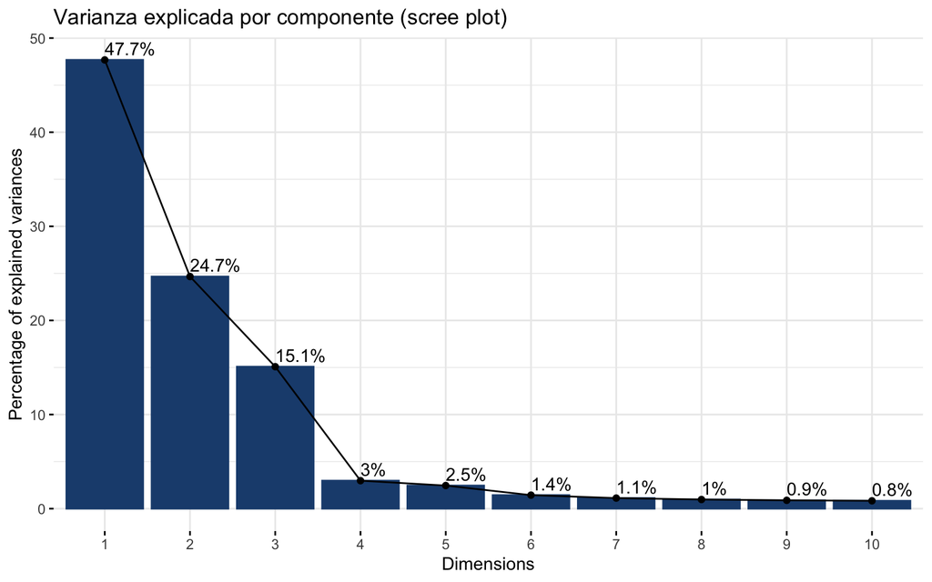

```r
# Scree plot: porcentaje de varianza explicada por cada componente. Se lee
# buscando el "codo": el punto a partir del cual añadir componentes aporta
# poco. Ahí decidimos cuántas componentes retener para resumir los datos.
fviz_eig(pca_apostadores, addlabels = TRUE,
         barfill = "#1e4c7d", barcolor = "#1e4c7d",
         main = "Varianza explicada por componente (scree plot)")
```

```r
# Varianza explicada en números (proporción y acumulada).
varianza_explicada <- summary(pca_apostadores)$importance
varianza_explicada[, 1:5]
```

```
                            PC1      PC2      PC3      PC4       PC5
Standard deviation     2.583682 1.858226 1.453243 0.645212 0.5862647
Proportion of Variance 0.476820 0.246640 0.150850 0.029740 0.0245500
Cumulative Proportion  0.476820 0.723460 0.874310 0.904050 0.9286000
```

```r
# Cargas (rotation): cuánto pesa cada variable original en cada componente.
# Aquí interpretamos QUÉ representan PC1 y PC2 según sus cargas.
cargas <- pca_apostadores$rotation[, 1:2] %>%
  round(2)
cargas
```

```
                              PC1   PC2
edad                         0.00 -0.43
antiguedad_dias             -0.24 -0.30
num_depositos_mes           -0.33  0.22
monto_total_depositado_mxn  -0.30 -0.21
monto_promedio_apuesta_mxn  -0.21 -0.34
num_apuestas_mes            -0.22  0.38
num_sesiones_mes            -0.31  0.27
duracion_sesion_min         -0.34  0.10
pct_apuestas_nocturnas      -0.33  0.15
num_juegos_distintos         0.16  0.22
pct_uso_bonos                0.15  0.33
indice_persecucion_perdidas -0.35  0.15
monto_total_retirado_mxn    -0.17 -0.27
perdida_neta_mxn            -0.36 -0.10
```

INTERPRETACIÓN DE LAS PRIMERAS COMPONENTES (leer la tabla ‘cargas’):

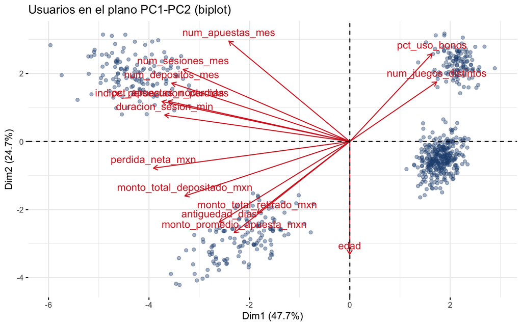

```r
# Biplot: proyección de los 700 usuarios en PC1-PC2 con las flechas de las
# variables. Variables con flechas casi paralelas están correlacionadas
# (esperamos ver juntas a depositado, retirado y pérdida neta).
fviz_pca_biplot(pca_apostadores,
                label = "var", col.var = "#d62828",
                col.ind = "#1e4c7d", alpha.ind = 0.4,
                title = "Usuarios en el plano PC1-PC2 (biplot)")
```

## 2. CLUSTERING — ELECCIÓN DE k CON EL MÉTODO DEL CODO Y k-MEANS

k-means necesita que fijemos k (número de grupos) de antemano. Lo elegimos a partir de los datos, no a ojo.

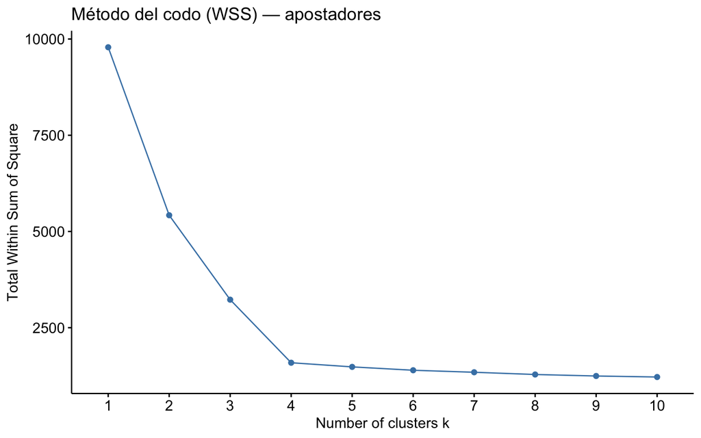

```r
# MÉTODO DEL CODO (WSS = suma de cuadrados dentro de los grupos):
# al aumentar k, la WSS siempre baja (más grupos => puntos más cerca de su
# centroide). Buscamos el "codo": el k a partir del cual el descenso se
# vuelve marginal (la curva se aplana). Ese codo sugiere el número de grupos:
# añadir más no compra mucha cohesión adicional.
set.seed(2026)
fviz_nbclust(apostadores_norm, kmeans, method = "wss", nstart = 20) +
  labs(title = "Método del codo (WSS) — apostadores")
```

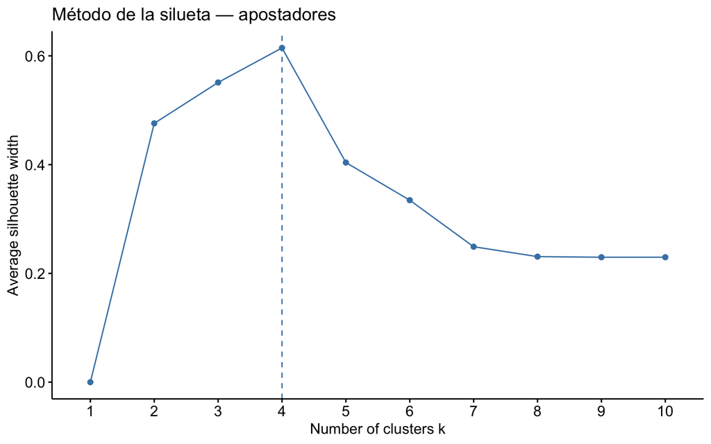

```r
# Confirmación con la silueta: para cada k mide qué tan bien separados quedan
# los grupos (cada punto cómodo en su grupo vs. cercano a otro). El k con
# silueta promedio MÁS ALTA es el preferido; sirve para desempatar si el codo
# fuera ambiguo.
set.seed(2026)
fviz_nbclust(apostadores_norm, kmeans, method = "silhouette", nstart = 20) +
  labs(title = "Método de la silueta — apostadores")
```

```r
# Tras leer el codo (se aplana en 4) y la silueta (máxima en 4), elegimos
# k = 4: cuatro perfiles de jugador.
k_elegido <- 4
```

```r
# K-MEANS CON EL k ELEGIDO
# nstart = 25: k-means depende de la inicialización aleatoria de centroides;
# probar 25 arranques y quedarse con el mejor evita caer en un óptimo local
# malo. set.seed() garantiza reproducibilidad.
set.seed(2026)
km_apostadores <- kmeans(apostadores_norm, centers = k_elegido, nstart = 25)
```

```r
# Tamaño de cada grupo (número de usuarios).
km_apostadores$size
```

```
[1] 130 120 130 320
```

```r
# PERFILADO DE LOS GRUPOS:
# Para interpretar QUÉ tipo de jugador es cada grupo, calculamos las medias de
# las variables ORIGINALES (no las normalizadas) por cluster. Así leemos las
# cifras en sus unidades reales (pesos, conteos, %, minutos).
apostadores_perfilados <- apostadores %>%
  mutate(cluster = factor(km_apostadores$cluster))
```

```r
perfil_clusters <- apostadores_perfilados %>%
  group_by(cluster) %>%
  summarise(across(everything(), ~ mean(.x, na.rm = TRUE)), n = n()) %>%
  ungroup()
perfil_clusters
```

```
# A tibble: 4 × 16
  cluster  edad antiguedad_dias num_depositos_mes monto_total_depositado_mxn
  <fct>   <dbl>           <dbl>             <dbl>                      <dbl>
1 1        45.1            873.              7.86                     26687.
2 2        26.9            224.              5.82                      4566.
3 3        31.7            609.             22.3                      15556.
4 4        40.3            429.              3.05                      1111.
# ℹ 11 more variables: monto_promedio_apuesta_mxn <dbl>,
#   num_apuestas_mes <dbl>, num_sesiones_mes <dbl>, duracion_sesion_min <dbl>,
#   pct_apuestas_nocturnas <dbl>, num_juegos_distintos <dbl>,
#   pct_uso_bonos <dbl>, indice_persecucion_perdidas <dbl>,
#   monto_total_retirado_mxn <dbl>, perdida_neta_mxn <dbl>, n <int>
```

INTERPRETACIÓN (leer ‘perfil_clusters’): Comparando las medias por grupo se reconocen perfiles de jugador, por ejemplo:

- recreativo / casual: depósitos y montos bajos, poca frecuencia, sesiones cortas, baja persecución de pérdidas (el grupo más grande);
- VIP / alto valor: depósitos y apuesta promedio muy altos, pérdida neta alta, frecuencia moderada (pocos usuarios, mucho ingreso para la casa);
- en riesgo / juego problemático: frecuencia altísima (muchas apuestas y sesiones), sesiones largas, alto % de juego nocturno e índice de persecución de pérdidas elevado, retiros bajos;
- cazador de bonos: uso de bonos muy alto, muchas apuestas de monto bajo, retiros que igualan o superan los depósitos (pérdida neta cercana a cero o negativa), sesiones cortas. El alumno debe etiquetar cada grupo según las cifras reales observadas y pensar qué tratamiento correspondería a cada uno (retención, atención de juego responsable, control de abuso de bonos, etc.).

## 3. GRÁFICA DE LOS CLUSTERS SOBRE LAS COMPONENTES DEL PCA (PASO 1)

Pedimos explícitamente graficar los puntos ya agrupados usando el PCA que calculamos en el paso 1. Tomamos las coordenadas de cada usuario en PC1 y PC2 (pca_apostadores$x) y las coloreamos por el cluster de k-means. Así vemos en 2D cómo se separan los cuatro perfiles sobre los ejes que más varianza concentran.

```r
# Porcentaje de varianza de PC1 y PC2 para rotular los ejes.
pct_pc1 <- round(varianza_explicada[2, 1] * 100, 1)
pct_pc2 <- round(varianza_explicada[2, 2] * 100, 1)
```

```r
# Tabla con las coordenadas PCA + el cluster asignado.
puntos_pca <- as_tibble(pca_apostadores$x[, 1:2]) %>%
  mutate(cluster = factor(km_apostadores$cluster))
```

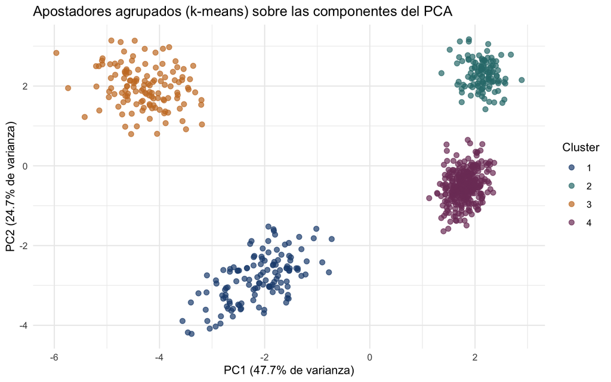

```r
ggplot(puntos_pca, aes(x = PC1, y = PC2, color = cluster)) +
  geom_point(alpha = 0.7, size = 2) +
  scale_color_manual(values = c("#1e4c7d", "#2d7a7a", "#c97b2a", "#7d3c66")) +
  labs(
    title = "Apostadores agrupados (k-means) sobre las componentes del PCA",
    x = paste0("PC1 (", pct_pc1, "% de varianza)"),
    y = paste0("PC2 (", pct_pc2, "% de varianza)"),
    color = "Cluster"
  ) +
  theme_minimal()
```

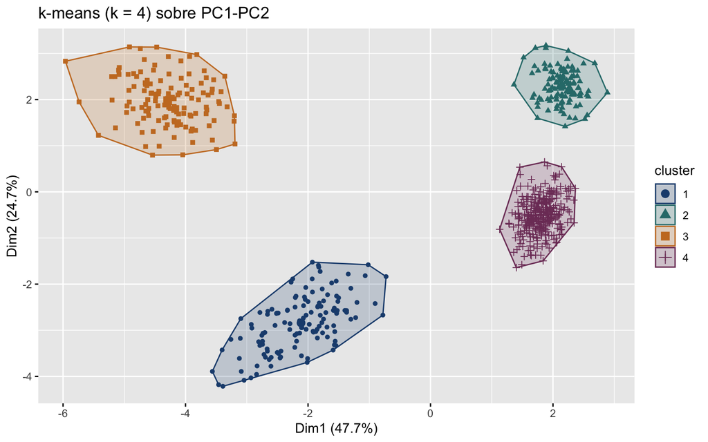

```r
# Alternativa equivalente con factoextra (proyecta sobre PC1-PC2 igual que
# arriba y añade elipses para resaltar cada grupo).
fviz_cluster(km_apostadores, data = apostadores_norm,
             geom = "point", ellipse.type = "convex",
             palette = c("#1e4c7d", "#2d7a7a", "#c97b2a", "#7d3c66"),
             main = paste0("k-means (k = ", k_elegido, ") sobre PC1-PC2"))
```

## 4. CLUSTERING JERÁRQUICO (comparación)

El clustering jerárquico no necesita fijar k de antemano: construye un árbol (dendrograma) fusionando usuarios/grupos por cercanía. Lo “cortamos” a la altura que deje el número de grupos deseado. Sirve para contrastar con k-means: si ambos encuentran la misma estructura, ganamos confianza.

```r
# Distancias euclidianas entre los 700 usuarios normalizados.
dist_apostadores <- dist(apostadores_norm, method = "euclidean")
```

```r
# Ward (ward.D2): tiende a formar grupos compactos y de tamaño parecido, lo
# que lo hace comparable con k-means.
hc_apostadores <- hclust(dist_apostadores, method = "ward.D2")
```

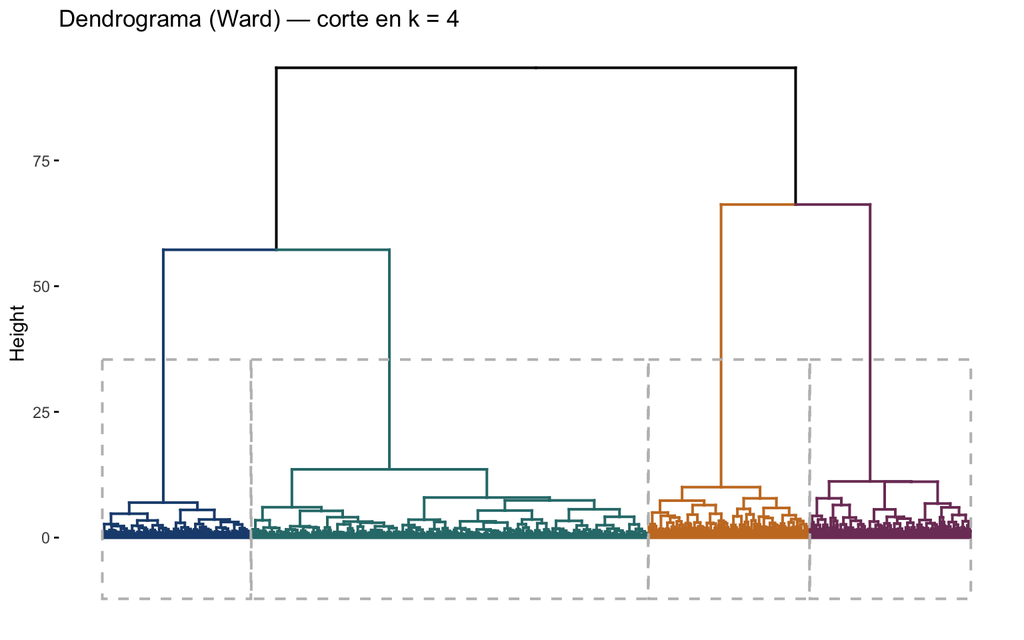

```r
# Dendrograma coloreado al mismo número de grupos que k-means.
fviz_dend(hc_apostadores, k = k_elegido,
          k_colors = c("#1e4c7d", "#2d7a7a", "#c97b2a", "#7d3c66"),
          show_labels = FALSE, rect = TRUE,
          main = paste0("Dendrograma (Ward) — corte en k = ", k_elegido))
```

```r
# Cortamos el árbol en k grupos.
grupos_hc <- cutree(hc_apostadores, k = k_elegido)
```

```r
# COMPARACIÓN k-means vs jerárquico:
# Las etiquetas de grupo son arbitrarias (el "1" de un método no tiene por qué
# ser el "1" del otro), así que NO miramos la diagonal: revisamos si cada
# grupo de un método cae mayormente en UN solo grupo del otro. Si la
# correspondencia es fuerte, ambos métodos descubren los mismos perfiles de
# jugador y eso da robustez a la segmentación.
table(kmeans = km_apostadores$cluster, jerarquico = grupos_hc)
```

```
      jerarquico
kmeans   1   2   3   4
     1   0 130   0   0
     2   0   0 120   0
     3   0   0   0 130
     4 320   0   0   0
```